# Final Project = Recommendation Systems

# Om Patel (8958837), Lakshay Soni (8888349)

A recommendation system is an artificial intelligence or AI algorithm, usually associated with machine learning, that uses Big Data to suggest or recommend additional products to consumers. These can be based on various criteria, including past purchases, search history, demographic information, and other factors. Recommender systems are highly useful as they help users discover products and services they might otherwise have not found on their own.

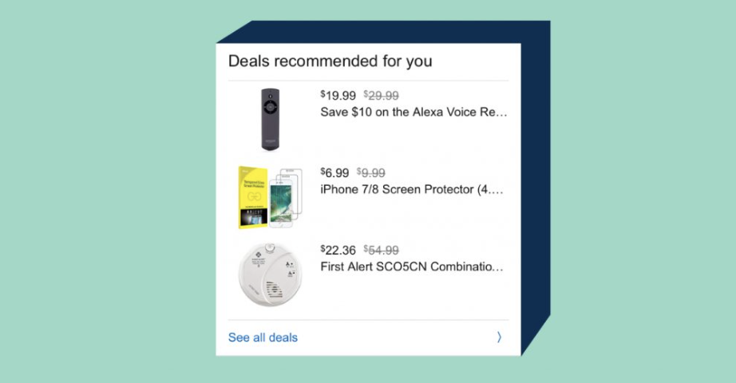

```python
# This Python 3 environment comes with many helpful analytics libraries installed
# It is defined by the kaggle/python Docker image: https://github.com/kaggle/docker-python
# For example, here's several helpful packages to load

import numpy as np # linear algebra
import pandas as pd # data processing, CSV file I/O (e.g. pd.read_csv)

# Input data files are available in the read-only "../input/" directory
# For example, running this (by clicking run or pressing Shift+Enter) will list all files under the input directory

import os
for dirname, _, filenames in os.walk('/kaggle/input'):
    for filename in filenames:
        print(os.path.join(dirname, filename))

# You can write up to 20GB to the current directory (/kaggle/working/) that gets preserved as output when you create a version using "Save & Run All"
# You can also write temporary files to /kaggle/temp/, but they won't be saved outside of the current session
```

```
/kaggle/input/amazon-sales-dataset/amazon.csv
```

```python
import numpy as np
import pandas as pd
```

```python
df = pd.read_csv('/kaggle/input/amazon-sales-dataset/amazon.csv')
df.head(3)
```

|  | product_id | product_name | category | discounted_price | actual_price | discount_percentage | rating | rating_count | about_product | user_id | user_name | review_id | review_title | review_content | img_link | product_link |
| --- | --- | --- | --- | --- | --- | --- | --- | --- | --- | --- | --- | --- | --- | --- | --- | --- |
| 0 | B07JW9H4J1 | Wayona Nylon Braided USB to Lightning Fast Cha... | Computers&Accessories\|Accessories&Peripherals\|... | ₹399 | ₹1,099 | 64% | 4.2 | 24,269 | High Compatibility : Compatible With iPhone 12... | AG3D6O4STAQKAY2UVGEUV46KN35Q,AHMY5CWJMMK5BJRBB... | Manav,Adarsh gupta,Sundeep,S.Sayeed Ahmed,jasp... | R3HXWT0LRP0NMF,R2AJM3LFTLZHFO,R6AQJGUP6P86,R1K... | Satisfied,Charging is really fast,Value for mo... | Looks durable Charging is fine tooNo complains... | https://m.media-amazon.com/images/W/WEBP_40237... | https://www.amazon.in/Wayona-Braided-WN3LG1-Sy... |
| 1 | B098NS6PVG | Ambrane Unbreakable 60W / 3A Fast Charging 1.5... | Computers&Accessories\|Accessories&Peripherals\|... | ₹199 | ₹349 | 43% | 4.0 | 43,994 | Compatible with all Type C enabled devices, be... | AECPFYFQVRUWC3KGNLJIOREFP5LQ,AGYYVPDD7YG7FYNBX... | ArdKn,Nirbhay kumar,Sagar Viswanathan,Asp,Plac... | RGIQEG07R9HS2,R1SMWZQ86XIN8U,R2J3Y1WL29GWDE,RY... | A Good Braided Cable for Your Type C Device,Go... | I ordered this cable to connect my phone to An... | https://m.media-amazon.com/images/W/WEBP_40237... | https://www.amazon.in/Ambrane-Unbreakable-Char... |
| 2 | B096MSW6CT | Sounce Fast Phone Charging Cable & Data Sync U... | Computers&Accessories\|Accessories&Peripherals\|... | ₹199 | ₹1,899 | 90% | 3.9 | 7,928 | 【 Fast Charger& Data Sync】-With built-in safet... | AGU3BBQ2V2DDAMOAKGFAWDDQ6QHA,AESFLDV2PT363T2AQ... | Kunal,Himanshu,viswanath,sai niharka,saqib mal... | R3J3EQQ9TZI5ZJ,R3E7WBGK7ID0KV,RWU79XKQ6I1QF,R2... | Good speed for earlier versions,Good Product,W... | Not quite durable and sturdy,https://m.media-a... | https://m.media-amazon.com/images/W/WEBP_40237... | https://www.amazon.in/Sounce-iPhone-Charging-C... |

```python
df.shape
```

```
(1465, 16)
```

```python
df.describe()
```

[output not shown]

## Data Cleaning & Pre Processing:

```python
def clean_values(value):
    # Split the value by comma and return the first part (User ID or User Name)
    return value.split(',')[0].strip()  # Change the index to [1] for User Name if needed

# Apply the function to clean up each column
df['user_id'] = df['user_id'].apply(clean_values)
df['user_name'] = df['user_name'].apply(clean_values)
df['review_id'] = df['review_id'].apply(clean_values)
df['review_title'] = df['review_title'].apply(clean_values)
```

```python
df.sample(3)
```

|  | product_id | product_name | category | discounted_price | actual_price | discount_percentage | rating | rating_count | about_product | user_id | user_name | review_id | review_title | review_content | img_link | product_link |
| --- | --- | --- | --- | --- | --- | --- | --- | --- | --- | --- | --- | --- | --- | --- | --- | --- |
| 335 | B0B3RRWSF6 | Fire-Boltt Phoenix Smart Watch with Bluetooth ... | Electronics\|WearableTechnology\|SmartWatches | ₹1,998 | ₹9,999 | 80% | 4.3 | 27,696 | Fire-Boltt is India' No 1 Wearable Watch Brand... | AHUGCKS7YANTMDYINXQG2UDTU4JQ | yogita ratre | R34816YEM3Y2VJ | 7-8/10 | 2 months review- its been working fine, there'... | https://m.media-amazon.com/images/I/41sHRWXCfv... | https://www.amazon.in/Fire-Boltt-Phoenix-Bluet... |
| 278 | B09HQSV46W | Mi 100 cm (40 inches) Horizon Edition Full HD ... | Electronics\|HomeTheater,TV&Video\|Televisions\|S... | ₹21,999 | ₹29,999 | 27% | 4.2 | 32,840 | Resolution : Full HD (1920x1080) resolution \| ... | AHEVOQADJSSRX7DS325HSFLMP7VQ | Manoj maddheshiya | R13UTIA6KOF6QV | It is the best tv if you are getting it in 10-12k | Pros- xiomi 5a is best in budget-Nice picture ... | https://m.media-amazon.com/images/W/WEBP_40237... | https://www.amazon.in/inches-Horizon-Android-L... |
| 175 | B09LHXNZLR | Skadioo WiFi Adapter for pc \| Car Accessories,... | Computers&Accessories\|NetworkingDevices\|Networ... | ₹199 | ₹499 | 60% | 3.7 | 612 | 【Powerful compatibility】 Compatible with TV bo... | AG2Q7FISK54KBSPHF7CNNGZ3GLNA | POTNURU RAJINI | R3U57AW0L6O5C6 | Good | Good,Its working is very nice with pc. Easy to... | https://m.media-amazon.com/images/W/WEBP_40237... | https://www.amazon.in/Skadioo-Accessories-Rece... |

```python
# finding unique values of customer_id
df['user_id'].value_counts()
```

```
user_id
AHIKJUDTVJ4T6DV6IUGFYZ5LXMPA    10
AG3D6O4STAQKAY2UVGEUV46KN35Q     8
AGAELRYPMTG5SADZPDYB343EASAA     8
AECPFYFQVRUWC3KGNLJIOREFP5LQ     8
AEWAZDZZJLQUYVOVGBEUKSLXHQ5A     7
                                ..
AH2QFGBZYKJDYPAKHEEXUKLZDYTQ     1
AEWM6BXJQ76ZA3JH3TEG3ORMEDCA     1
AFUWVHBC2SCTJ7VEAWEIEYW5V4KA     1
AFR7NDA6QYOPSCNJIDXRDRHJIYXA     1
AFGW5PT3R6ZAVQR4Y5MWVAKBZAYA     1
Name: count, Length: 1170, dtype: int64
```

```python
df.isnull().sum()
```

```
product_id             0
product_name           0
category               0
discounted_price       0
actual_price           0
discount_percentage    0
rating                 0
rating_count           2
about_product          0
user_id                0
user_name              0
review_id              0
review_title           0
review_content         0
img_link               0
product_link           0
dtype: int64
```

```python
df = df.dropna()
```

Lets extract main features required for the model building and removing features like image link, product link and so on.

```python
main_feature4m_df = df[['user_id', 'product_id', 'product_name', 'about_product', 'category', 'rating', 'rating_count', 'discounted_price', 'actual_price', 'review_title', 'review_content']]
```

```python
main_feature4m_df.rating.unique()
```

```
array(['4.2', '4.0', '3.9', '4.1', '4.3', '4.4', '4.5', '3.7', '3.3',
       '3.6', '3.4', '3.8', '3.5', '4.6', '3.2', '5.0', '4.7', '3.0',
       '2.8', '4', '3.1', '4.8', '2.3', '|', '2', '3', '2.6', '2.9'],
      dtype=object)
```

> We can see that there is an unexpected reting value shown like '|' which has no meaning in it. So, we are going to igonere that part of data.

```python
# removing the rows with rating | error terms
main_feature4m_df.shape
```

```
(1463, 11)
```

```python
# cleaning the ratings column which has unwanted values "|" as rating.
main_feature4m_df = main_feature4m_df[main_feature4m_df['rating'] != '|']
main_feature4m_df.shape
```

```
(1462, 11)
```

```python
main_feature4m_df.dtypes
```

```
user_id             object
product_id          object
product_name        object
about_product       object
category            object
rating              object
rating_count        object
discounted_price    object
actual_price        object
review_title        object
review_content      object
dtype: object
```

We also have to convert this data types into appropriate formation.

```python
# converting the column to appropriate data type from object
main_feature4m_df['rating'] = main_feature4m_df['rating'].astype(float)
main_feature4m_df['rating_count'] = main_feature4m_df['rating_count'].str.replace(",",'')  # removing , from the numbers
main_feature4m_df['rating_count'] = main_feature4m_df['rating_count'].astype('float64')
main_feature4m_df['discounted_price'] = main_feature4m_df['discounted_price'].str.replace("₹",'')
main_feature4m_df['discounted_price'] = main_feature4m_df['discounted_price'].str.replace(",",'')
main_feature4m_df['discounted_price'] = main_feature4m_df['discounted_price'].astype('float64')
main_feature4m_df['actual_price'] = main_feature4m_df['actual_price'].str.replace("₹",'')
main_feature4m_df['actual_price'] = main_feature4m_df['actual_price'].str.replace(",",'')
main_feature4m_df['actual_price'] = main_feature4m_df['actual_price'].astype('float64')
main_feature4m_df['user_id'] = main_feature4m_df['user_id'].astype(str)
main_feature4m_df['product_id'] = main_feature4m_df['product_id'].astype(str)
main_feature4m_df['category'] = main_feature4m_df['category'].astype(str)
main_feature4m_df['product_name'] = main_feature4m_df['product_name'].astype(str)
main_feature4m_df['about_product'] = main_feature4m_df['about_product'].astype(str)
main_feature4m_df['review_title'] = main_feature4m_df['review_title'].astype(str)
main_feature4m_df['review_content'] = main_feature4m_df['review_content'].astype(str)

main_feature4m_df.dtypes
```

```
user_id              object
product_id           object
product_name         object
about_product        object
category             object
rating              float64
rating_count        float64
discounted_price    float64
actual_price        float64
review_title         object
review_content       object
dtype: object
```

Now, cleaning the category column.

```python
# checking category
main_feature4m_df['category'].head(3)
```

```
0    Computers&Accessories|Accessories&Peripherals|...
1    Computers&Accessories|Accessories&Peripherals|...
2    Computers&Accessories|Accessories&Peripherals|...
Name: category, dtype: object
```

```python
nw_cat = main_feature4m_df['category'].str.split('|', expand=True)
nw_cat
```

|  | 0 | 1 | 2 | 3 | 4 | 5 | 6 |
| --- | --- | --- | --- | --- | --- | --- | --- |
| 0 | Computers&Accessories | Accessories&Peripherals | Cables&Accessories | Cables | USBCables | None | None |
| 1 | Computers&Accessories | Accessories&Peripherals | Cables&Accessories | Cables | USBCables | None | None |
| 2 | Computers&Accessories | Accessories&Peripherals | Cables&Accessories | Cables | USBCables | None | None |
| 3 | Computers&Accessories | Accessories&Peripherals | Cables&Accessories | Cables | USBCables | None | None |
| 4 | Computers&Accessories | Accessories&Peripherals | Cables&Accessories | Cables | USBCables | None | None |
| ... | ... | ... | ... | ... | ... | ... | ... |
| 1460 | Home&Kitchen | Kitchen&HomeAppliances | WaterPurifiers&Accessories | WaterPurifierAccessories | None | None | None |
| 1461 | Home&Kitchen | Kitchen&HomeAppliances | SmallKitchenAppliances | Rice&PastaCookers | None | None | None |
| 1462 | Home&Kitchen | Heating,Cooling&AirQuality | RoomHeaters | HeatConvectors | None | None | None |
| 1463 | Home&Kitchen | Heating,Cooling&AirQuality | Fans | ExhaustFans | None | None | None |
| 1464 | Home&Kitchen | Kitchen&HomeAppliances | SmallKitchenAppliances | SandwichMakers | None | None | None |

1462 rows × 7 columns

```python
# adding the 2 new columns to the main dataframe
nw_cat['category_1'] = nw_cat[0]
nw_cat['category_2'] = nw_cat[1]
```

```python
main_feature4m_df.drop('category', axis=1, inplace=True)
main_feature4m_df['category_1'] = nw_cat['category_1']
main_feature4m_df['category_2'] = nw_cat['category_2']
```

```python
main_feature4m_df["category_1"].value_counts()
```

```
category_1
Electronics              526
Computers&Accessories    451
Home&Kitchen             447
OfficeProducts            31
MusicalInstruments         2
HomeImprovement            2
Toys&Games                 1
Car&Motorbike              1
Health&PersonalCare        1
Name: count, dtype: int64
```

```python
main_feature4m_df["category_2"].value_counts()
```

```
category_2
Accessories&Peripherals                    379
Kitchen&HomeAppliances                     307
HomeTheater,TV&Video                       162
Mobiles&Accessories                        161
Heating,Cooling&AirQuality                 116
WearableTechnology                          76
Headphones,Earbuds&Accessories              66
NetworkingDevices                           34
OfficePaperProducts                         27
ExternalDevices&DataStorage                 18
Cameras&Photography                         16
HomeStorage&Organization                    16
HomeAudio                                   16
GeneralPurposeBatteries&BatteryChargers     14
Accessories                                 14
Printers,Inks&Accessories                   11
CraftMaterials                               7
Components                                   5
OfficeElectronics                            4
Electrical                                   2
Monitors                                     2
Microphones                                  2
Arts&Crafts                                  1
PowerAccessories                             1
Tablets                                      1
Laptops                                      1
Kitchen&Dining                               1
CarAccessories                               1
HomeMedicalSupplies&Equipment                1
Name: count, dtype: int64
```

```python
main_feature4m_df.isna().sum()
```

```
user_id             0
product_id          0
product_name        0
about_product       0
rating              0
rating_count        0
discounted_price    0
actual_price        0
review_title        0
review_content      0
category_1          0
category_2          0
dtype: int64
```

```python
main_feature4m_df['category_1'] = main_feature4m_df['category_1'].str.replace('&', 'and')
main_feature4m_df['category_1'] = main_feature4m_df['category_1'].str.replace('OfficeProducts', 'Office Products')
main_feature4m_df['category_1'] = main_feature4m_df['category_1'].str.replace('MusicalInstruments', 'Musical Instruments')
main_feature4m_df['category_1'] = main_feature4m_df['category_1'].str.replace('HomeImprovement', 'Home Improvement')

main_feature4m_df['category_2'] = main_feature4m_df['category_2'].str.replace('&', 'and')
main_feature4m_df['category_2'] = main_feature4m_df['category_2'].str.replace(',', ', ')
main_feature4m_df['category_2'] = main_feature4m_df['category_2'].str.replace('HomeAppliances', 'Home Appliances')
main_feature4m_df['category_2'] = main_feature4m_df['category_2'].str.replace('AirQuality', 'Air Quality')
main_feature4m_df['category_2'] = main_feature4m_df['category_2'].str.replace('WearableTechnology', 'Wearable Technology')
main_feature4m_df['category_2'] = main_feature4m_df['category_2'].str.replace('NetworkingDevices', 'Networking Devices')
main_feature4m_df['category_2'] = main_feature4m_df['category_2'].str.replace('OfficePaperProducts', 'Office Paper Products')
main_feature4m_df['category_2'] = main_feature4m_df['category_2'].str.replace('ExternalDevices', 'External Devices')
main_feature4m_df['category_2'] = main_feature4m_df['category_2'].str.replace('DataStorage', 'Data Storage')
main_feature4m_df['category_2'] = main_feature4m_df['category_2'].str.replace('HomeStorage', 'Home Storage')
main_feature4m_df['category_2'] = main_feature4m_df['category_2'].str.replace('HomeAudio', 'Home Audio')
main_feature4m_df['category_2'] = main_feature4m_df['category_2'].str.replace('GeneralPurposeBatteries', 'General Purpose Batteries')
main_feature4m_df['category_2'] = main_feature4m_df['category_2'].str.replace('BatteryChargers', 'Battery Chargers')
main_feature4m_df['category_2'] = main_feature4m_df['category_2'].str.replace('CraftMaterials', 'Craft Materials')
main_feature4m_df['category_2'] = main_feature4m_df['category_2'].str.replace('OfficeElectronics', 'Office Electronics')
main_feature4m_df['category_2'] = main_feature4m_df['category_2'].str.replace('PowerAccessories', 'Power Accessories')
main_feature4m_df['category_2'] = main_feature4m_df['category_2'].str.replace('CarAccessories', 'Car Accessories')
main_feature4m_df['category_2'] = main_feature4m_df['category_2'].str.replace('HomeMedicalSupplies', 'Home Medical Supplies')
main_feature4m_df['category_2'] = main_feature4m_df['category_2'].str.replace('HomeTheater', 'Home Theater')
```

```python
main_feature4m_df.sample(3)
```

[output not shown]

```python
main_feature4m_df.shape
```

```
(1462, 12)
```

# EDA & Data Visualization:

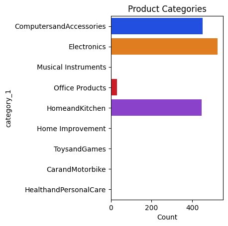

```python
# Set the color palette
sns.set_palette('bright')

# Create multiple visualizations
# plt.figure(figsize=(10, 30))

# Plotting a bar chart of product categories
plt.subplot(1, 2, 1)
sns.countplot(data=main_feature4m_df, y='category_1')
plt.title('Product Categories')
plt.xlabel('Count')
```

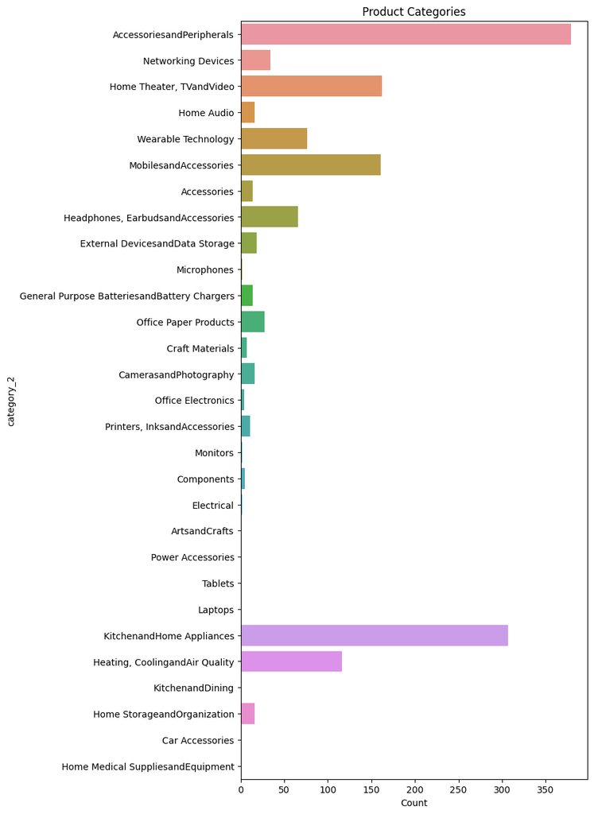

```python
# Set the color palette
sns.set_palette('bright')

# Create multiple visualizations
plt.figure(figsize=(15, 15))

# Plotting a bar chart of product categories
plt.subplot(1, 2, 1)
sns.countplot(data=main_feature4m_df, y='category_2')
plt.title('Product Categories')
plt.xlabel('Count')
```

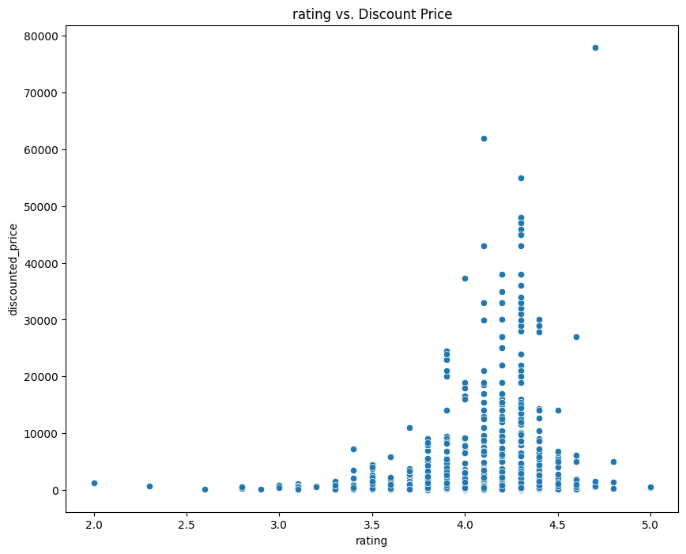

```python
import matplotlib.pyplot as plt
import seaborn as sns

plt.figure(figsize=(10, 8))
sns.scatterplot(x='rating', y='discounted_price', data=main_feature4m_df)
plt.title('rating vs. Discount Price')
plt.show()
```

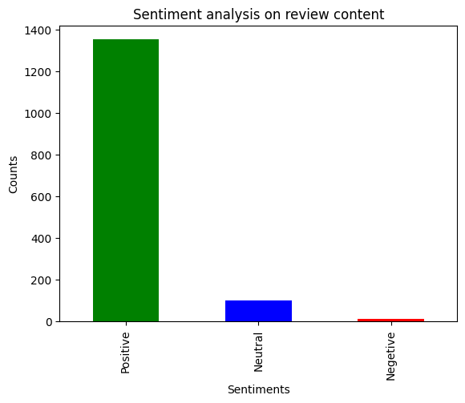

```python
from textblob import TextBlob

# Classify Sentiment
def senti_als(text):
    analysis = TextBlob(text)
    # threshold for positive & negetive polarity
    if analysis.sentiment.polarity > 0.1:
        return 'Positive'
    elif analysis.sentiment.polarity < -0.1:
        return 'Negetive'
    else:
        return 'Neutral'


# apply sentiment analysis on review_content

sentimen = main_feature4m_df['review_content'].apply(senti_als)
sentiment_count = sentimen.value_counts()

# plot the bar

sentiment_count.plot(kind='bar',color=['green','blue','red'],title="Sentiment analysis on review content")
plt.xlabel('Sentiments')
plt.ylabel('Counts')
plt.show()
```

scorce: https://www.kaggle.com/code/sauravdas07/recommendation-engine-3-0#Preprocess-the-data

Making Word cloud for insights about reviews of customers.

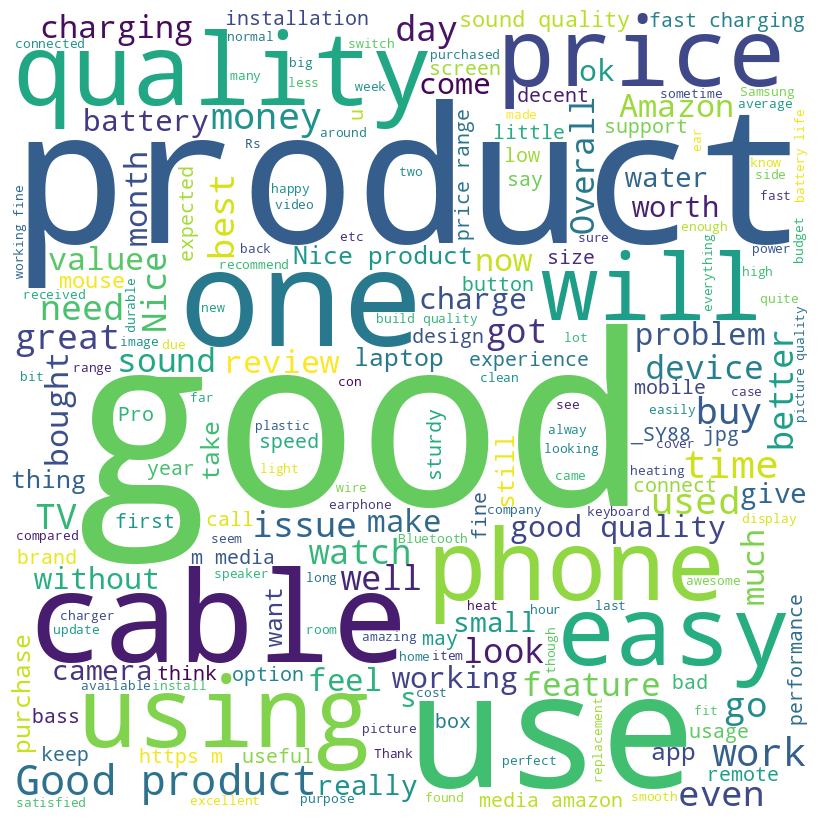

```python
from wordcloud import WordCloud

product_text = ' '.join(main_feature4m_df['review_content'].dropna().values)
wordcloud = WordCloud(width=800, height=800, background_color='white', min_font_size=10).generate(product_text)
plt.figure(figsize=(8, 8), facecolor=None)
plt.imshow(wordcloud)
plt.axis("off")
plt.tight_layout(pad=0)
plt.show()
```

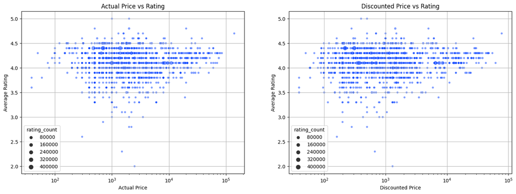

```python
fig, axes = plt.subplots(1, 2, figsize=(18, 6))

# actual price vs rating
sns.scatterplot(ax=axes[0], data=main_feature4m_df, x='actual_price', y='rating', size='rating_count', alpha=0.5)
axes[0].set_title('Actual Price vs Rating')
axes[0].set_xlabel('Actual Price')
axes[0].set_ylabel('Average Rating')
axes[0].set_xscale('log')
axes[0].grid(True)

# discounted price vs rating
sns.scatterplot(ax=axes[1], data=main_feature4m_df, x='discounted_price', y='rating', size='rating_count', alpha=0.5)
axes[1].set_title('Discounted Price vs Rating')
axes[1].set_xlabel('Discounted Price')
axes[1].set_ylabel('Average Rating')
axes[1].set_xscale('log')
axes[1].grid(True)

plt.show()
```

```python
import plotly.express as px

# Create an interactive 3D scatter plot with Plotly
fig = px.scatter_3d(main_feature4m_df, x='actual_price', y='discounted_price', z='rating', color='rating',
                     hover_data=['product_name'], title='Interactive 3D Scatter Plot')
fig.show()
```

[interactive chart not shown]

## 1. Content Based Filtering Recommender System

In essence, content-based recommender systems are those that leverage user recommendations derived from item descriptions. Content-based systems operate under the premise that if a user has responded favorably to goods with particular characteristics, she needs to have an interest in things that are comparable and said to share those characteristics. The most popular ways to characterize an item's features are with keywords and their weights, which indicate how crucial the keywords are to the item's description.

It uses following formula in order to calculate similarity.

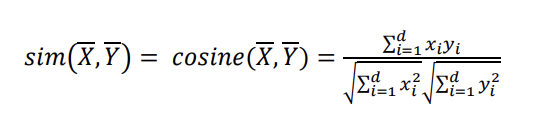

[figure not shown]

```python
main_feature4m_df['product_details'] = main_feature4m_df['product_name'] + ' ' + main_feature4m_df['about_product'] + ' ' + main_feature4m_df['about_product'] + ' ' + main_feature4m_df['review_content']
```

```python
main_feature4m_df['product_details'] = main_feature4m_df['product_details'].fillna('')
```

```python
from sklearn.feature_extraction.text import TfidfVectorizer

tfidf_vec = TfidfVectorizer(stop_words='english',max_df=0.95,min_df=2,ngram_range=(1,1))
tfidf_matrix = tfidf_vec.fit_transform(main_feature4m_df['product_details'])
```

```python
# tfidf_matrix is a sparse matrix means it has lot of zeros in it.
tfidf_matrix.shape
```

```
(1462, 10088)
```

```python
from sklearn.metrics.pairwise import linear_kernel

cosine_sim = linear_kernel(tfidf_matrix, tfidf_matrix)
sim_score = 0

def content_based_recommendations(product_id, data, cosine_sim, n=5):
    idx = data[data['product_id'] == product_id].index[0]
    sim_scores = list(enumerate(cosine_sim[idx]))
    sim_scores = sorted(sim_scores, key=lambda x: x[1], reverse=True)
    sim_scores = sim_scores[1:n+1]
    product_indices = [i[0] for i in sim_scores]
    return data.iloc[product_indices], sim_scores

content_based_recommendations, p_sim_score = content_based_recommendations('B09LHXNZLR', main_feature4m_df, cosine_sim)
```

```python
content_based_recommendations
```

|  | user_id | product_id | product_name | about_product | rating | rating_count | discounted_price | actual_price | review_title | review_content | category_1 | category_2 | product_details |
| --- | --- | --- | --- | --- | --- | --- | --- | --- | --- | --- | --- | --- | --- |
| 170 | AGYAPOCHJTBVSKV3GSONJ7VXL3PA | B07M69276N | TP-Link AC1300 USB WiFi Adapter (Archer T3U) -... | Ultimate Wi-Fi Speed —— AC1300 (400 Mpbs on 2.... | 4.4 | 23169.0 | 1399.0 | 2499.0 | Good device and makes your laptop to utilize m... | Good device and makes your laptop to utilize m... | ComputersandAccessories | Networking Devices | TP-Link AC1300 USB WiFi Adapter (Archer T3U) -... |
| 56 | AGV3IEFANZCKECFGUM42MRH5FNOA | B0088TKTY2 | TP-LINK WiFi Dongle 300 Mbps Mini Wireless Net... | 300 Mbps Wi-Fi —— 300Mbps wireless speed ideal... | 4.2 | 179691.0 | 649.0 | 1399.0 | Works on linux for me. Get the model with ante... | I use this to connect an old PC to internet. I... | ComputersandAccessories | Networking Devices | TP-LINK WiFi Dongle 300 Mbps Mini Wireless Net... |
| 50 | AHDFR3PDKEBV72HXRL3RJJLS3YYA | B07P681N66 | TP-Link AC600 600 Mbps WiFi Wireless Network U... | High-Speed Wi-Fi —— 256QAM support increases t... | 4.4 | 24780.0 | 1199.0 | 2199.0 | Works flawlessly on Ubuntu 22.04 (if installed... | I am using this on an old Mac Mini, since the ... | ComputersandAccessories | Networking Devices | TP-Link AC600 600 Mbps WiFi Wireless Network U... |
| 894 | AHDFR3PDKEBV72HXRL3RJJLS3YYA | B07P681N66 | TP-Link AC600 600 Mbps WiFi Wireless Network U... | High-Speed Wi-Fi —— 256QAM support increases t... | 4.4 | 24780.0 | 1199.0 | 2199.0 | Works flawlessly on Ubuntu 22.04 (if installed... | I am using this on an old Mac Mini, since the ... | ComputersandAccessories | Networking Devices | TP-Link AC600 600 Mbps WiFi Wireless Network U... |
| 303 | AFWESPH2F54JGI3PJYU2NINBVCAQ | B08G43CCLC | NK STAR 950 Mbps USB WiFi Adapter Wireless Net... | [NOTE - >>Not Support to DVR and HDTV]..[CONNE... | 4.2 | 163.0 | 218.0 | 999.0 | Thank you | Valu money good quality products,Checked it, w... | ComputersandAccessories | Networking Devices | NK STAR 950 Mbps USB WiFi Adapter Wireless Net... |

```python
# finding ground truth score using ratings
recommended_product_ids = content_based_recommendations['product_id'].tolist()
ratings_for_recommended_items = main_feature4m_df[main_feature4m_df['product_id'].isin(recommended_product_ids)]

# Define a threshold for considering an item as relevant (e.g., 4 or 5 stars)
threshold = 4

# Assign binary relevance labels based on the threshold
ground_truth = [1 if rating >= threshold else 0 for rating in ratings_for_recommended_items['rating']]

predicted_scores = [tup[1] for tup in p_sim_score]
print("Predicted Relevance Scores:", predicted_scores)
```

```
Predicted Relevance Scores: [0.4449764139013784, 0.40585660588882244, 0.3941487259864262, 0.3941487259864262, 0.390363185974582]
```

**The evaluation** involves calculation of average precision for a recommended list of length N defined as follows:

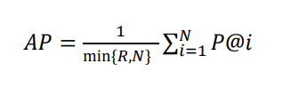

where R is the total number of relevant items in the repository. In the case that R is less than N, averaging the precision values by R instead of N is more intuitive as otherwise a recommender system would be wrongfully penalized for recommending N items even if it correctly places all R relevant items to the top of the recommended list.

```python
from sklearn.metrics import average_precision_score

ap = average_precision_score(ground_truth, predicted_scores)
print("Average Precision (AP):", ap)
```

```
Average Precision (AP): 1.0
```

## 2. Collaborative Filtering Recommendations

Collaborative filtering is a recommendation system technique that suggests items to users based on the preferences of other users. Instead of analyzing item attributes, collaborative filtering relies on the patterns of user interactions with items to make recommendations.

Content filtering, by contrast, uses the attributes or features of an item (this is the content part) to recommend other items similar to the user’s preferences. This approach is based on similarity of item and user features, given information about a user and items they have interacted with (e.g. a user’s age, the category of a restaurant’s cuisine, the average review for a movie), model the likelihood of a new interaction.

[figure not shown]

```python
from surprise import Dataset, Reader, accuracy
from surprise.model_selection import train_test_split
from surprise import KNNBasic

reader = Reader(rating_scale=(1, 5))
data = Dataset.load_from_df(main_feature4m_df[['user_id', 'product_id', 'rating']], reader)

# Split dataset into train and test sets
trainset, testset = train_test_split(data, test_size=0.2, random_state=42)

# Build and train user-based collaborative filtering model
sim_options = {'name': 'cosine', 'user_based': True}  # User-based CF model meaning that the similarity is calculated between users
model = KNNBasic(sim_options=sim_options)
model.fit(trainset)

# Make predictions
predictions = model.test(testset)

# Evaluate model
accuracy.rmse(predictions)
accuracy.mae(predictions)
```

```
Computing the cosine similarity matrix...
Done computing similarity matrix.
RMSE: 0.2636
MAE:  0.1829
```

```
0.18286800363193648
```

```python
predictions[0:5]
```

```
[Prediction(uid='AHH26HAPTOI5Z52DFLNYU5TOLWCQ', iid='B08M66K48D', r_ui=4.3, est=4.097091531223268, details={'was_impossible': True, 'reason': 'User and/or item is unknown.'}),
 Prediction(uid='AH2OGGTXFZ6MSSCZB7IRRZPFOJLA', iid='B08MCD9JFY', r_ui=3.8, est=4.097091531223268, details={'was_impossible': True, 'reason': 'User and/or item is unknown.'}),
 Prediction(uid='AEYYS445R5U3OMTCXTPFPPYIOC3A', iid='B07YQ5SN4H', r_ui=4.0, est=4.097091531223268, details={'was_impossible': True, 'reason': 'User and/or item is unknown.'}),
 Prediction(uid='AHBISYTXOMEMKDTXVEKH57D2X3RA', iid='B07W7Z6DVL', r_ui=4.1, est=4.097091531223268, details={'was_impossible': True, 'reason': 'User and/or item is unknown.'}),
 Prediction(uid='AFZESR4UNHIMTL2SQMFA3FJYKHAQ', iid='B09J4YQYX3', r_ui=4.4, est=4.097091531223268, details={'was_impossible': True, 'reason': 'User and/or item is unknown.'})]
```

For the first prediction, the model estimated the rating for user 'AHH26HAPTOI5Z52DFLNYU5TOLWCQ' for item 'B08M66K48D' to be approximately 4.097. However, the actual rating ('r_ui') was 4.3.

Similarly, for the second and third predictions, the model estimated the ratings for the corresponding users and items to be approximately 4.097, but the actual ratings were 3.8 and 4.0, respectively.

# Singular Value Decomposition (SVD)

SVD is a matrix factorization technique commonly used in collaborative filtering to reduce the dimensionality of the user-item interaction matrix and uncover latent factors that capture underlying patterns in the data. It decomposes the user-item interaction matrix into three matrices: U, Σ, and V^T, where U represents user features, Σ represents singular values, and V^T represents item features.

Matrix factorization is a dimensionality reduction technique used in collaborative filtering. The idea is to represent the user-item interaction matrix as the product of two lower-dimensional matrices: one representing users and the other representing items. These matrices are called user and item latent factor matrices. MF can be used to calculate the similarity in user’s ratings or interactions to provide recommendations. In the simple user item matrix below, Ted and Carol like movies B and C. Bob likes movie B. To recommend a movie to Bob, matrix factorization calculates that users who liked B also liked C, so C is a possible recommendation for Bob.

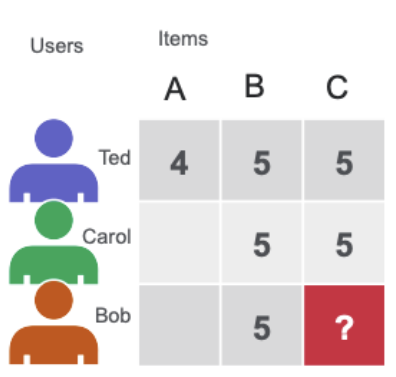

```python
from surprise import SVD
from surprise import Dataset
from surprise.model_selection import cross_validate

reader = Reader(rating_scale=(1, 5))
data = Dataset.load_from_df(main_feature4m_df[['user_id', 'product_id', 'rating']], reader)

# Split dataset into train and test sets
trainset, testset = train_test_split(data, test_size=0.2)

# Train SVD model
algo = SVD()
algo.fit(trainset)

# Make predictions for test set
predictions = algo.test(testset)

# Evaluate predictions
accuracy.rmse(predictions)

# Print a few example predictions
for prediction in predictions[:5]:
    print('User:', prediction.uid)
    print('Item:', prediction.iid)
    print('Actual Rating:', prediction.r_ui)
    print('Predicted Rating:', prediction.est)
    print()
```

```
RMSE: 0.2629
User: AGA2PZGWMQIRA46VYOTICFE7KCBA
Item: B002PD61Y4
Actual Rating: 4.1
Predicted Rating: 4.061991070198029

User: AFOBWTUOP4PHZ5K7XW4SPJWKDIKQ
Item: B09SGGRKV8
Actual Rating: 3.6
Predicted Rating: 4.0980325064157395

User: AH3MVZYHGOVNKO5T5EWVT4HK6M7A
Item: B00LVMTA2A
Actual Rating: 4.4
Predicted Rating: 4.0980325064157395

User: AHTJVOG52ZROVUFB64P2TTWIUCYQ
Item: B08235JZFB
Actual Rating: 4.1
Predicted Rating: 4.0980325064157395

User: AFQ44B5ISCXUWKFHZL7HTRTYWZKA
Item: B07YNTJ8ZM
Actual Rating: 3.9
Predicted Rating: 4.0980325064157395
```

The performance of the collaborative filtering model is evaluated using metrics such as Root Mean Squared Error (RMSE) or Mean Absolute Error (MAE), which measure the difference between predicted and actual ratings on a test set. Here, Ratings serve as indicators of user satisfaction or interest in the items, and they form the basis for making personalized recommendations to users.

```python
# Run cross-validation to evaluate the model
results = cross_validate(algo, data, measures=['RMSE', 'MAE'], cv=5, verbose=True)

# Print results
print("Mean RMSE:", results['test_rmse'].mean())
print("Mean MAE:", results['test_mae'].mean())
```

```
Evaluating RMSE, MAE of algorithm SVD on 5 split(s).

                  Fold 1  Fold 2  Fold 3  Fold 4  Fold 5  Mean    Std
RMSE (testset)    0.2638  0.2665  0.2758  0.3203  0.2822  0.2817  0.0204
MAE (testset)     0.1918  0.1902  0.2011  0.2162  0.2166  0.2032  0.0114
Fit time          0.03    0.03    0.03    0.03    0.03    0.03    0.00
Test time         0.00    0.00    0.00    0.00    0.00    0.00    0.00
Mean RMSE: 0.2817325851796576
Mean MAE: 0.20317135709514553
```